# Template code for logistic regression and ggplot (for bee data analysis)

# **Generate figures**

## Bargraph

In the following code, we generate a bar graph from the test data. First we need to create a data frame so that ggplot can extract information to generate a bar graph. Second we create another data frame called meanpoints where we store the mean value of each bee so that we can plot the mean choices of each individual bee. To edit the first data frame for your own data, you can replace yellow and blue with the different conditions in your experiment, then add the mean values in the proportion column in the same order as how you listed your conditions in the condition column (i.e. if you have three conditions, you will instead have 3 means to list in the proportion column. The same is true for the confidence bounds). Remember to check your final dataframe to make sure the proportions and confidence intervals are properly corresponding to each condition.

```r
dframe <- data.frame(condition = rep(c("Yellow","Blue")), # Create dataframe where there is a column called condition and rows called yellow and blue
                legend = c("Y","B"),
                proportion = c(0.62,0.7), # Add a new column called proportion with rows that have the following values, corresponding to the mean of yellow and blue. To easily find the mean use the mean() function e.g. mean(btest$CHOICE)
                confintlow = c(yconfintlow,bconfintlow), # Add confintlow column including the lower confidence bound values for yellow and blue
                confinthigh = c(yconfinthigh,bconfinthigh)) # Add confinthigh column including the upper confidence bound values for yellow and blue
dframe$condition <- as.factor(dframe$condition) # Make sure the conditions are treated as factors for the new dataframe, if not done it will cause errors


meanpoints <- test %>%   # Calculate mean of each block for each bee
  group_by(BEEID, CONDITION) %>%
  summarize(prop = mean(CHOICE))
```

```r
  colnames(meanpoints)[2] ="condition" # THIS IS SUPER IMPORTANT! rename column to match dframe, because the column name needs to match the dframe as we want to plot both in the same graph
  levels(meanpoints$condition) <- tolower(levels(meanpoints$condition)) # rename condition names to match
  levels(meanpoints$condition) <- str_to_title(levels(meanpoints$condition)) # recapitalize condition names
```

Now let’s generate the figure.

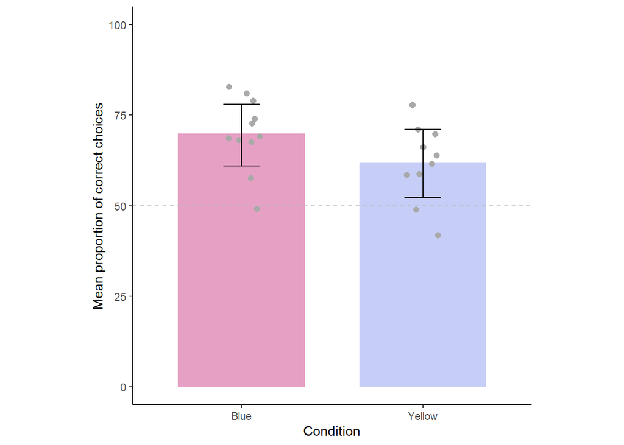

```r
testgraph <- ggplot(dframe, aes(x = condition, y = proportion, fill = condition)) +
  labs (x= "Condition", y = "Mean proportion of correct choices", fill="Condition") +
  geom_bar(stat = "identity", position = "dodge", width = .7) +
  geom_hline(yintercept = 0.5, linetype = "dashed", colour = "grey") +
  geom_point(data = meanpoints, aes(x = condition, y = prop), position = position_jitter(width=0.1), size =2, colour="dark grey") +
  scale_fill_manual(values = wes_palette("GrandBudapest2", n = 2)) +
  geom_errorbar(aes(ymin = confintlow, ymax = confinthigh), width=.2) +
  scale_y_continuous(labels = scales::percent_format(accuracy = 1, suffix = NULL), limits = c(0,1)) +
  theme(panel.background = element_blank(),
        axis.line = element_line(colour = "black"),
        aspect.ratio = 1/1,
        legend.position = "none")
print(testgraph)
```

Sometimes you want to rearrange the default order of your conditions/factors because ggplot will plot the conditions in ascending order by default, please peruse the following code which may help you with this.

```r
levels(meanpoints$condition) # view the existing order of factors in the meanpoints
levels(dframe$condition)
meanpoints$condition <- factor(meanpoints$condition, levels=c('Yellow', 'Blue')) # set the order of your factors as you wish
levels(meanpoints$condition) # check to view the change

dframe$condition # View the existing order of factors in the dframe
dframe$condition <- factor(dframe$condition, levels = c('Yellow', 'Blue')) # change the order of conditions in your dframe to match if they aren't matching those in meanpoints
dframe$condition # check to view the change
```

After changing this order, plot the same graph and see how the order of the bars change.

You may also want to plot a more complicated graph involving 2 factors, here is an example of how to achieve it. In this example we not only have ‘condition’ as a factor but also ‘temperature’. Let’s first generate the models and confidence intervals for this graph, the important thing is to first subset your data so that each model is only using data for one condition combination. As we already subsetted bees trained to blue vs yellow, we can further subset again for each temperature group:

```r
btesthigh <- subset(btest, TEMPERATURE == "HIGH")
btestmoderate <- subset(btest, TEMPERATURE == "MODERATE")
btestlow <- subset(btest, TEMPERATURE == "LOW")
btesthighmean <- mean(btesthigh$CHOICE)
btestmoderatemean <- mean(btestmoderate$CHOICE)
btestlowmean <- mean(btestlow$CHOICE)

ytesthigh <- subset(ytest, TEMPERATURE == "HIGH")
ytestmoderate <- subset(ytest, TEMPERATURE == "MODERATE")
ytestlow <- subset(ytest, TEMPERATURE == "LOW")
ytesthighmean <- mean(ytesthigh$CHOICE)
ytestmoderatemean <- mean(ytestmoderate$CHOICE)
ytestlowmean <- mean(ytestlow$CHOICE)

bluehighlm <- glmer(CHOICE~ 1 + (1|BEEID), family = binomial, data = btesthigh) # we want to create individual models for each condition combination, these will represent individual bars in your graph
summary(bluehighlm)
bluemoderatelm <- glmer(CHOICE~ 1 + (1|BEEID), family = binomial, data = btestmoderate)
summary(bluemoderatelm)
bluelowlm <- glmer(CHOICE~ 1 + (1|BEEID), family = binomial, data = btestlow)
summary(bluelowlm)

yellowhighlm <- glmer(CHOICE~ 1 + (1|BEEID), family = binomial, data = ytesthigh)
summary(yellowhighlm)
yellowmoderatelm <- glmer(CHOICE~ 1 + (1|BEEID), family = binomial, data = ytestmoderate)
summary(yellowmoderatelm)
yellowlowlm <- glmer(CHOICE~ 1 + (1|BEEID), family = binomial, data = ytestlow)
summary(yellowlowlm)

confint(bluehighlm) #confidence interval
bhighconfintlow<-(exp(0.05282346)/(1 + exp(0.05282346))) #reverse link function
bhighconfinthigh<-(exp(1.512154)/(1 + exp(1.512154)))

confint(bluemoderatelm) #confidence interval
bmoderateconfintlow<-(exp(0.1904898)/(1 + exp(0.1904898))) #reverse link function
bmoderateconfinthigh<-(exp(1.583801)/(1 + exp(1.583801)))

confint(bluelowlm) #confidence interval
blowconfintlow<-(exp(0.2229423)/(1 + exp(0.2229423))) #reverse link function
blowconfinthigh<-(exp(1.934828)/(1 + exp(1.934828)))

confint(yellowhighlm) #confidence interval
yhighconfintlow<-(exp(-0.4007427)/(1 + exp(-0.4007427))) #reverse link function
yhighconfinthigh<-(exp(1.053893)/(1 + exp(1.053893)))

confint(yellowmoderatelm) #confidence interval
ymoderateconfintlow<-(exp(-0.327433)/(1 + exp(-0.327433))) #reverse link function
ymoderateconfinthigh<-(exp(1.180353)/(1 + exp(1.180353)))

confint(yellowlowlm) #confidence interval
ylowconfintlow<-(exp(0.04692103)/(1 + exp(0.04692103))) #reverse link function
ylowconfinthigh<-(exp(1.781464)/(1 + exp(1.781464)))
```

```r
dframe2 <- data.frame(condition = rep(c("Yellow","Blue")),
                temperature = c("High","Moderate","Low"),
                proportion = c(1,2,3,4,5,6),
                confintlow = c(1,2,3,4,5,6),
                confinthigh = c(1,2,3,4,5,6))
view(dframe2)
```

We now input the proportion and confint information in the correct order as in the dataframe.

```r
dframe2 <- data.frame(condition = rep(c("Yellow","Blue")), # Create dataframe where there is a column called condition and rows called yellow and blue
                temperature = c("High","Moderate","Low"),
                proportion = c(ytesthighmean,btesthighmean,ytestmoderatemean,btestmoderatemean,ytestlowmean,btestlowmean), # Add a new column called proportion with rows that have the following values, corresponding to the mean of yellow and blue
                confintlow = c(yhighconfintlow,bhighconfintlow,ymoderateconfintlow,bmoderateconfintlow,ylowconfintlow,blowconfintlow), # Add confintlow column including the lower confidence bound values for yellow and blue
                confinthigh = c(yhighconfinthigh,bhighconfinthigh,ymoderateconfinthigh,bmoderateconfinthigh,ylowconfinthigh,blowconfinthigh)) # Add confinthigh column including the upper confidence bound values for yellow and blue

dframe2$condition <- as.factor(dframe2$condition) # Make sure the conditions are treated as factors for the new dataframe, if not done it will cause errors
dframe2$temperature <- as.factor(dframe2$temperature)

meanpoints2 <- test %>%   # Calculate mean of each block for each bee
  group_by(BEEID, CONDITION, TEMPERATURE) %>% # this time add the new condition TEMPERATURE
  summarize(prop = mean(CHOICE))
```

```r
colnames(meanpoints2)[2] ="condition" # THIS IS SUPER IMPORTANT! rename column to match dframe, because the column name needs to match the dframe as we want to plot both in the same graph
  colnames(meanpoints2)[3] ="temperature"
  levels(meanpoints2$condition) <- tolower(levels(meanpoints2$condition))
  levels(meanpoints2$condition) <- str_to_title(levels(meanpoints2$condition))
  levels(meanpoints2$temperature) <- tolower(levels(meanpoints2$temperature))
  levels(meanpoints2$temperature) <- str_to_title(levels(meanpoints2$temperature)) # If you find any errors for these make sure the conditions are factors


dframe2$temperature # View the existing order of factors in the dframe
```

```
## [1] High     Moderate Low      High     Moderate Low
## Levels: High Low Moderate
```

```r
dframe2$temperature <- factor(dframe2$temperature, levels = c('High', 'Moderate','Low')) # change the order of conditions in your dframe to match if they aren't matching those in meanpoints
dframe2$temperature # check to view the change
```

```
## [1] High     Moderate Low      High     Moderate Low
## Levels: High Moderate Low
```

Now finally create the graph. Common issues are usually due to the names of conditions being not exactly the same between the dframe and the meanpoints, OR the conditions are not coded as factors in your new dframe, OR the error bar ggplot code is grouping the wrong condition.

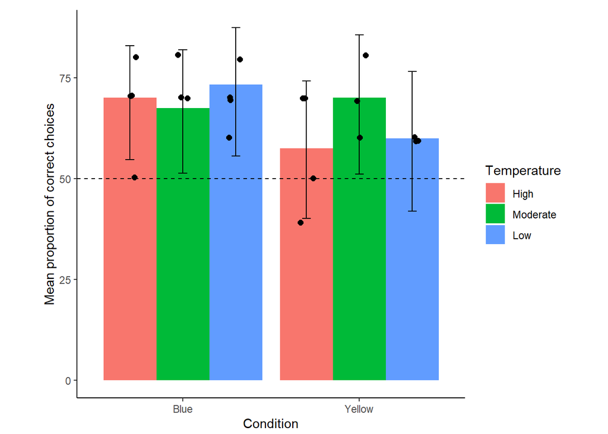

```r
testgraph_complex <- ggplot()+
  labs (x= "Condition", y = "Mean proportion of correct choices",  fill = "Temperature") +
  geom_bar(data = dframe2, aes(x = condition, y = proportion, fill = temperature), stat = "identity", position = "dodge") +
  geom_hline(yintercept = 0.5, linetype = "dashed", colour = " black") +
  geom_point(data = meanpoints2, aes(x = condition, y = prop, fill = temperature), position = position_jitterdodge(jitter.width=0.2, jitter.height = 0.01, dodge.width = 0.9),       show.legend = FALSE, size =2, colour="black") +
geom_errorbar(data = dframe2, aes(x = condition, y = proportion, ymin = confintlow, ymax = confinthigh, group = temperature), width=.15, position=position_dodge(.9)) +
  scale_y_continuous(labels = scales::percent_format(accuracy = 1, suffix = NULL))+
  theme(panel.background = element_blank(),
        axis.line = element_line(colour = "black"),
        aspect.ratio = 1/1,
        plot.margin = margin(0.3,0.3,0.1,0.4, "cm"))
testgraph_complex
```

## Scatter graph

Alternatively if you don’t like bar graphs you can remove the bars and simply show the error bars

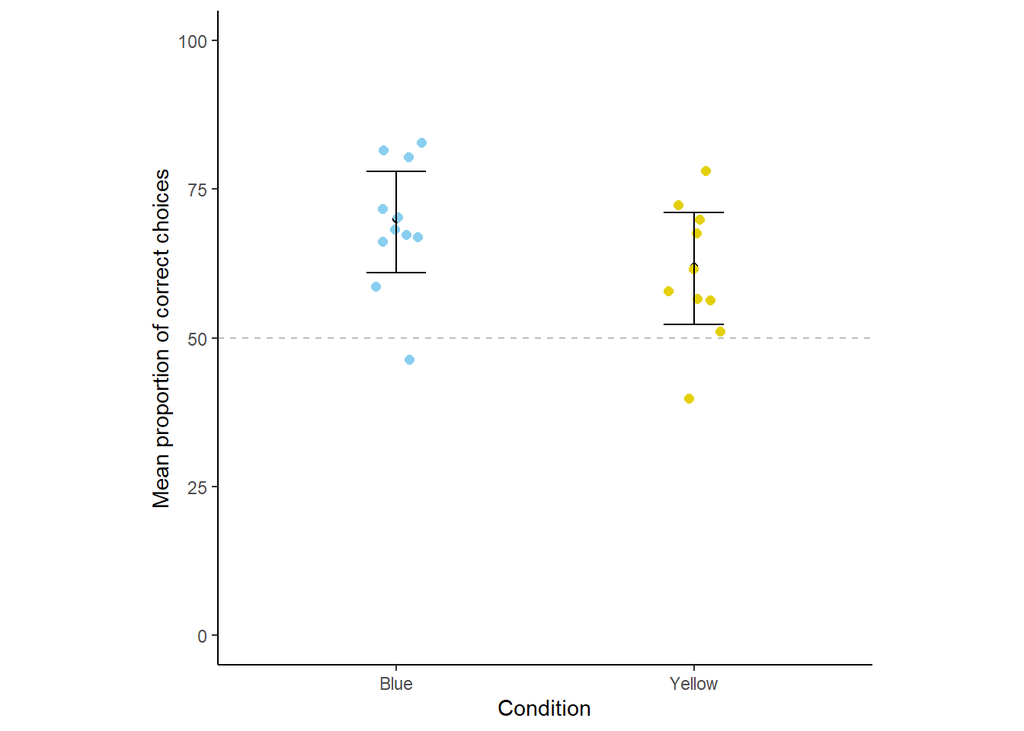

```r
testgraph2 <- ggplot(dframe, aes(x = condition, y = proportion, fill = condition)) +
  geom_hline(yintercept = 0.5, linetype = "dashed", colour = "grey") +
  labs (x= "Condition", y = "Mean proportion of correct choices", fill="Condition") +
  geom_point(data = dframe, aes(x = condition, y = proportion),
             position = position_dodge(width = 0.9), colour = "black") +
  geom_point(data = meanpoints, aes(x = condition, y = prop, colour = condition), position = position_jitter(width=0.1), size =2) +
  geom_errorbar(aes(ymin = confintlow, ymax = confinthigh), width=.2) +
  scale_y_continuous(labels = scales::percent_format(accuracy = 1, suffix = NULL), limits = c(0,1)) +
  scale_colour_manual(values = c("#89CFF0", "#E4D00A")) +
  theme(panel.background = element_blank(),
        axis.line = element_line(colour = "black"),
        aspect.ratio = 1/1,
        legend.position = "none")
print(testgraph2)
```

## Line graph

```r
blockmean <- btraining %>%   # calculate mean of each block for each bee
  group_by(BEEID, BLOCK) %>%
  summarize(prop = mean(CHOICE))
allmean <- blockmean %>%  #calculate mean of each block for all bees
  group_by(BLOCK) %>%
  summarise(proportion = mean(prop), sd = sd(prop))
str(allmean)
```

```
## tibble [4 × 3] (S3: tbl_df/tbl/data.frame)
##  $ BLOCK     : Factor w/ 4 levels "5","10","15",..: 1 2 3 4
##  $ proportion: num [1:4] 0.64 0.68 0.84 0.94
##  $ sd        : num [1:4] 0.0843 0.1687 0.1838 0.0966
```

Now generate the figure. Note if the error bars look weird it’s usually because it goes outside the y axi, in which case just extend the y axis slightly.

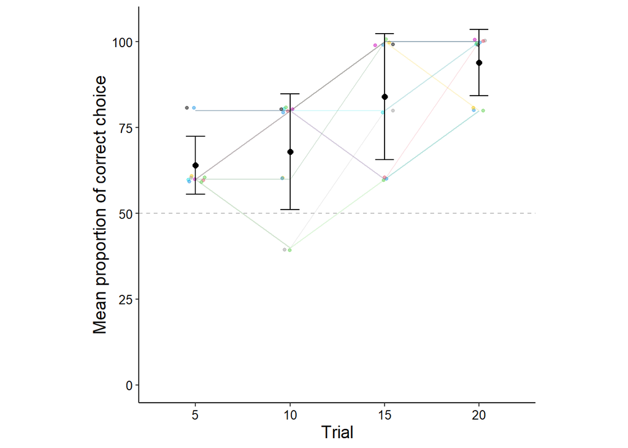

```r
learningcurve <- ggplot(blockmean,
                            aes(x = BLOCK,
                                y = prop,
                                group = factor(BEEID)))+
  geom_hline(yintercept = 0.5, linetype = "dashed", colour = "grey") +
  geom_jitter(size = 1, alpha = 0.5, width = 0.1, height = 0.01, colour = blockmean$BEEID) +
  geom_line(size = 0.5, alpha = 0.2, colour = blockmean$BEEID) +
  geom_point(data = blockmean,
             aes(x = "5",
                 y = allmean$proportion[1]), size = 2) +
  geom_point(data = blockmean,
             aes(x = "10",
                 y = allmean$proportion[2]), size = 2) +
  geom_point(data = blockmean,
             aes(x = "15",
                 y = allmean$proportion[3]), size = 2) +
   geom_point(data = blockmean,
             aes(x = "20",
                 y = allmean$proportion[4]), size = 2) +
  geom_errorbar(data = blockmean,
                aes( x = "5",
                     ymin = allmean$proportion[1] - allmean$sd[1],
                     ymax = allmean$proportion[1] + allmean$sd[1]), width = .2) +
  geom_errorbar(data = blockmean,
                aes( x = "10",
                     ymin = allmean$proportion[2] - allmean$sd[2],
                     ymax = allmean$proportion[2] + allmean$sd[2]), width = .2) +
  geom_errorbar(data = blockmean,
                aes( x = "15",
                     ymin = allmean$proportion[3] - allmean$sd[3],
                     ymax = allmean$proportion[3] + allmean$sd[3]), width = .2) +
   geom_errorbar(data = blockmean,
                aes( x = "20",
                     ymin = allmean$proportion[4] - allmean$sd[4],
                     ymax = allmean$proportion[4] + allmean$sd[4]), width = .2) +
  scale_y_continuous(labels = scales::percent_format(accuracy = 1, suffix = NULL), limits = c(0,1.05)) + # suffix = NULL to remove % on the y labels
  xlab("Trial") +
  ylab("Mean proportion of correct choice") +
  theme(axis.title.x = element_text(size = 14),
        axis.text.x  = element_text(size = 10, colour = "black"),
        axis.title.y = element_text(size = 14, vjust = 1),
        axis.text.y = element_text(size = 10, colour = "black")) +
  scale_color_gradient() +
  theme(panel.background = element_blank(),
        axis.line = element_line(colour = "black"),
        aspect.ratio = 1/1)
print(learningcurve)
```

## Figure with predicted values

As seen above, the line graph often looks messy. What we often do in publications is produce a figure based on the predicted values of our regression model.The first thing we need to do is generate predicted data points. Importantly you cannot do this for intercept only models because you need to have trial/choice number in the model.

```r
choicenumlm  <- data.frame (TRIAL = seq(1,20, length.out = 20)) # Create dataframe from 1 to 20 (20 was the max trial number)
Xgc1 <- model.matrix(~TRIAL, data = choicenumlm) # Create matrix of choice number
coeff <- c(as.numeric(btraininglm2$coefficients[1]), as.numeric(btraininglm2$coefficients[2])) # Create vector of model coefficients pulled from lm1
eta <- Xgc1 %*% coeff # Calculate predicted mean proportion of correct choices
SE <- sqrt(diag(Xgc1 %*% vcov(btraininglm2) %*% t(Xgc1))) # Calculate standard errors
```

Now that we have x, y values, we can create a dataframe for ggplot

```r
PREDLM <- data.frame (TRIAL = choicenumlm$TRIAL, ETA  = eta, STDERR = SE) # Create and add to a new dataframe
PREDLM$CONFINTLOW <-(PREDLM$ETA - 1.96*PREDLM$STDERR)  # Calculate confint lower bound
PREDLM$CONFINTHIGH <-(PREDLM$ETA + 1.96*PREDLM$STDERR) # Calculate confint upper bound
PREDLM$EXPETA <- (exp(PREDLM$ETA)/(1 + exp(PREDLM$ETA))) # Reverse the link function of the predicted mean proportion of correct choices
PREDLM$EXPCONFINTLOW <- (exp(PREDLM$CONFINTLOW)/(1 + exp(PREDLM$CONFINTLOW))) # Reverse the link function of the lower bound
PREDLM$EXPCONFINTHIGH <- (exp(PREDLM$CONFINTHIGH)/(1 +exp(PREDLM$CONFINTHIGH))) # Reverse the link function of the upper bound
```

And then generate a figure using ggplot using this dataframe

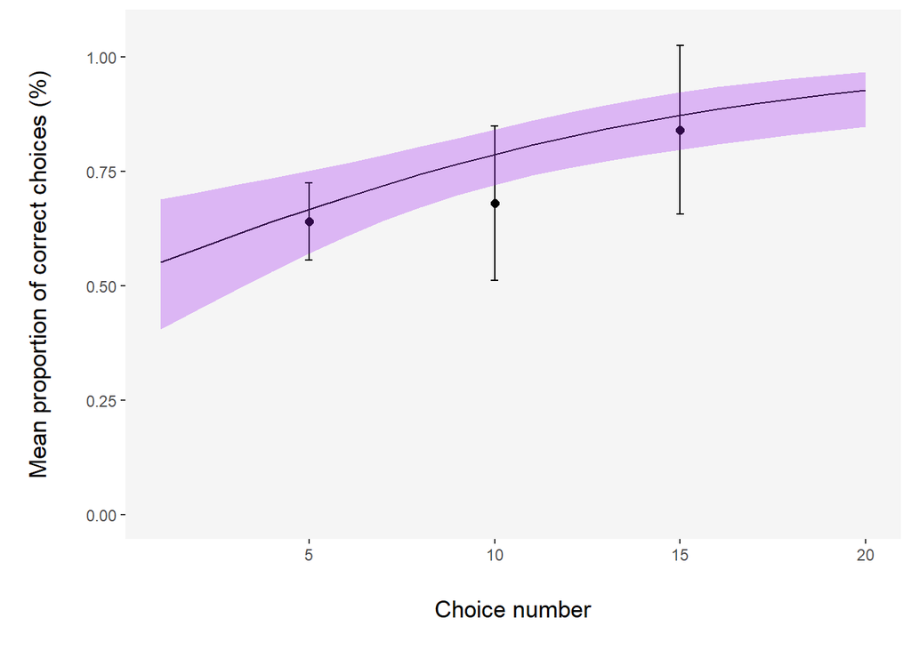

```r
Regfig <- ggplot() +
  geom_line(aes(x = TRIAL, y = EXPETA), size = 0.5, data = PREDLM) +

  annotate("point", x = 5,  y = allmean$proportion[1], size = 2) +
  annotate("point", x = 10, y = allmean$proportion[2], size = 2) +
  annotate("point", x = 15, y = allmean$proportion[3], size = 2) +

  annotate("errorbar",
           x = 5,
           ymin = allmean$proportion[1] - allmean$sd[1],
           ymax = allmean$proportion[1] + allmean$sd[1],
           width = 0.2) +

  annotate("errorbar",
           x = 10,
           ymin = allmean$proportion[2] - allmean$sd[2],
           ymax = allmean$proportion[2] + allmean$sd[2],
           width = 0.2) +

  annotate("errorbar",
           x = 15,
           ymin = allmean$proportion[3] - allmean$sd[3],
           ymax = allmean$proportion[3] + allmean$sd[3],
           width = 0.2) +

  scale_y_continuous(limits = c(0, 1.05)) +

  geom_ribbon(aes(x = TRIAL,
                  ymin = EXPCONFINTLOW,
                  ymax = EXPCONFINTHIGH),
              fill = "purple", alpha = 0.3,
              data = PREDLM) +

  theme(panel.grid.major = element_blank(),
        panel.grid.minor = element_blank(),
        panel.background = element_rect(fill = "gray96")) +

  theme(axis.title = element_text(size = 13),
        axis.title.y = element_text(margin = margin(0,20,0,10)),
        axis.title.x = element_text(margin = margin(20,0,10,0))) +

  labs(x = "Choice number",
       y = "Mean proportion of correct choices (%)")

print(Regfig)
```

What if you want to plot multiple models in one figure? Simply calculate the model predictions independently and then plot them together in ggplot. Below we will calculate the predicted values of the yellow training model and plot them alongside the previous predicted values. We will add the new data to the previous dataframe for ggplot. Note: Please refer to the explanation for blockmean and allmean in the Line graph explanation.

```r
coeff2 <- c(as.numeric(ytraininglm2$coefficients[1]), as.numeric(ytraininglm2$coefficients[2])) # Create vector of model coefficients pulled from lm2
eta2 <- Xgc1 %*% coeff2 # Calculate predicted mean proportion of correct choices
SE2 <- sqrt(diag(Xgc1 %*% vcov(ytraininglm2) %*% t(Xgc1))) # Calculate standard errors


PREDLM$ETA2 <- eta2 # Add mean proportion of correct choices to existing dataframe
PREDLM$STDERR2 <- SE2 # Add standard error to existing dataframe
PREDLM$CONFINTLOW2 <- (PREDLM$ETA2 - 1.96*PREDLM$STDERR2) # Calculate confint lower bound
PREDLM$CONFINTHIGH2 <- (PREDLM$ETA2 + 1.96*PREDLM$STDERR2) # Calculate confint upper bound
PREDLM$EXPETA2 <- (exp(PREDLM$ETA2)/(1 + exp(PREDLM$ETA2))) # Reverse the link function of the predicted mean proportion of correct choices
PREDLM$EXPCONFINTLOW2 <- (exp(PREDLM$CONFINTLOW2)/(1 + exp(PREDLM$CONFINTLOW2))) # Reverse the link function of the lower bound
PREDLM$EXPCONFINTHIGH2 <- (exp(PREDLM$CONFINTHIGH2)/(1 +exp(PREDLM$CONFINTHIGH2))) # Reverse the link function of the upper bound


blockmean2 <- ytraining %>%   # calculate mean of each block for each bee
  group_by(BEEID, BLOCK) %>%
  summarize(prop = mean(CHOICE))
allmean2 <- blockmean2 %>%  #calculate mean of each block for all bees
  group_by(BLOCK) %>%
  summarise(proportion = mean(prop), sd = sd(prop))
str(allmean2)
```

```
## tibble [4 × 3] (S3: tbl_df/tbl/data.frame)
##  $ BLOCK     : Factor w/ 4 levels "5","10","15",..: 1 2 3 4
##  $ proportion: num [1:4] 0.56 0.62 0.62 0.56
##  $ sd        : num [1:4] 0.126 0.148 0.114 0.184
```

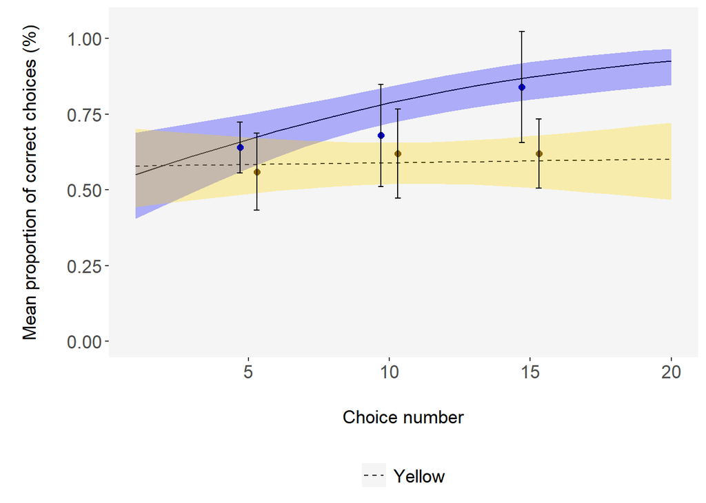

```r
Regfig2 <- ggplot() +

  geom_line(aes(x = TRIAL, y = EXPETA), size = 0.5, data = PREDLM) +
  geom_line(aes(x = TRIAL, y = EXPETA2, linetype = "dashed"),
            size = 0.5, data = PREDLM) +

  scale_y_continuous(limits = c(0, 1.05)) +

  geom_ribbon(aes(x = TRIAL,
                  ymin = EXPCONFINTLOW,
                  ymax = EXPCONFINTHIGH),
              fill = "blue", alpha = 0.3,
              data = PREDLM) +

  geom_ribbon(aes(x = TRIAL,
                  ymin = EXPCONFINTLOW2,
                  ymax = EXPCONFINTHIGH2),
              fill = "gold", alpha = 0.3,
              data = PREDLM) +

  # ---------------- BLUE MODEL ----------------
  annotate("point", x = 4.7,  y = allmean$proportion[1], size = 2, color = "blue3") + # manually putting the error bars at these locations on the figure
  annotate("point", x = 9.7,  y = allmean$proportion[2], size = 2, color = "blue3") +
  annotate("point", x = 14.7, y = allmean$proportion[3], size = 2, color = "blue3") +

  annotate("errorbar",
           x = 4.7,
           ymin = allmean$proportion[1] - allmean$sd[1],
           ymax = allmean$proportion[1] + allmean$sd[1],
           width = 0.2) +

  annotate("errorbar",
           x = 9.7,
           ymin = allmean$proportion[2] - allmean$sd[2],
           ymax = allmean$proportion[2] + allmean$sd[2],
           width = 0.2) +

  annotate("errorbar",
           x = 14.7,
           ymin = allmean$proportion[3] - allmean$sd[3],
           ymax = allmean$proportion[3] + allmean$sd[3],
           width = 0.2) +

  # ---------------- GOLD MODEL ----------------
  annotate("point", x = 5.3,  y = allmean2$proportion[1], size = 2, color = "darkgoldenrod4") + # manually putting the error bars at these locations on the figure
  annotate("point", x = 10.3, y = allmean2$proportion[2], size = 2, color = "darkgoldenrod4") +
  annotate("point", x = 15.3, y = allmean2$proportion[3], size = 2, color = "darkgoldenrod4") +

  annotate("errorbar",
           x = 5.3,
           ymin = allmean2$proportion[1] - allmean2$sd[1],
           ymax = allmean2$proportion[1] + allmean2$sd[1],
           width = 0.2) +

  annotate("errorbar",
           x = 10.3,
           ymin = allmean2$proportion[2] - allmean2$sd[2],
           ymax = allmean2$proportion[2] + allmean2$sd[2],
           width = 0.2) +

  annotate("errorbar",
           x = 15.3,
           ymin = allmean2$proportion[3] - allmean2$sd[3],
           ymax = allmean2$proportion[3] + allmean2$sd[3],
           width = 0.2) +

  # theme
  theme(
    panel.grid.major = element_blank(),
    panel.grid.minor = element_blank(),
    panel.background = element_rect(fill = "gray96"),
    axis.text = element_text(size = 13),
    axis.title = element_text(size = 13),
    legend.position = "bottom",
    legend.title = element_blank(),
    legend.text = element_text(size = 13),
    axis.title.y = element_text(margin = margin(0,20,0,10)),
    axis.title.x = element_text(margin = margin(20,0,10,0))
  ) +

  labs(x = "Choice number",
       y = "Mean proportion of correct choices (%)") +

  scale_linetype_identity(guide = "legend",
                          labels = c("Yellow", "Blue"))

print(Regfig2)
```

# **Further detail on ggplot2**

ggplot2 is simple to understand. Let’s go through each line of the bar graph. First you need to define the dataframe you want to plot in ggplot2. We then use “aes” to tell ggplot how you want the variables to match to different aesthetics/visual properties. This means that if you have two conditions for example, ggplot will know to allocate two different colours to represent each condition. NOTE: You can also manually define colours outside of “aes”, if you do this ggplot will not automatically map these colours to an aesthetic.

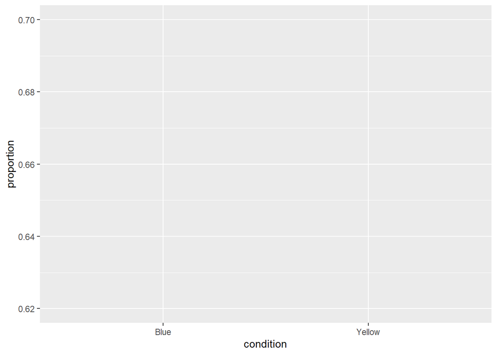

```r
testgraph <- ggplot(dframe, aes(x = condition, y = proportion, fill = condition))
print(testgraph)
```

You can see that ggplot has plotted the space for your data, now you can add geoms which are the different layers of commands for your graph. Let’s add the bars and x/y labels, we do this by simplying adding a “+” at the end of each line.

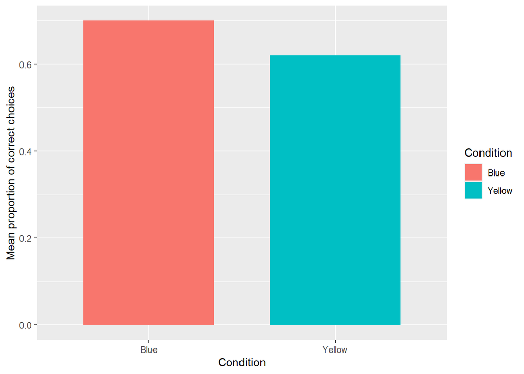

```r
testgraph <- ggplot(dframe, aes(x = condition, y = proportion, fill = condition)) +
  labs (x= "Condition", y = "Mean proportion of correct choices", fill="Condition") +
  geom_bar(stat = "identity", position = "dodge", width = .7) # stat identity tells ggplot that you are provided your own y values for the bar heights
print(testgraph) # dodge tells ggplot how far apart you want your bars
```

Let’s continue to add more geoms, let’s add error bars and raw data. Notice that you can map individual aesthetics for each geom type. Also note that we apply jitter to the raw data in geom_point to tell ggplot to spread out the points (i.e. jittering) slightly instead of overlapping them on top of each other.

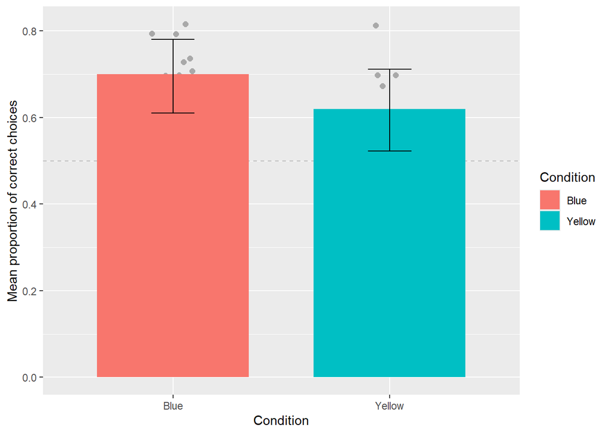

```r
testgraph <- ggplot(dframe, aes(x = condition, y = proportion, fill = condition)) +
  labs (x= "Condition", y = "Mean proportion of correct choices", fill="Condition") +
   geom_hline(yintercept = 0.5, linetype = "dashed", colour = "grey") +
  geom_point(data = meanpoints, aes(x = condition, y = prop), position = position_jitter(width=0.1), size =2, colour="dark grey") +
  geom_bar(stat = "identity", position = "dodge", width = .7) +
  geom_errorbar(aes(ymin = confintlow, ymax = confinthigh), width=.2)
print(testgraph)
```

It seems the the bars and grey dotted line are hiding some of the data. This is because ggplot maps each layer sequentially, if we move the geom point layer below the geom bar then ggplot will graph the points last on top of the bars. Let’s also add a custom colour palette to the graph, we can specify this using scale_fill_manual to tell ggplot to extract 2 (i.e. n = 2) colours from this palette to map to aesthetics. NOTE: alternatively you can specify exact hex colours (see scatter graph section).

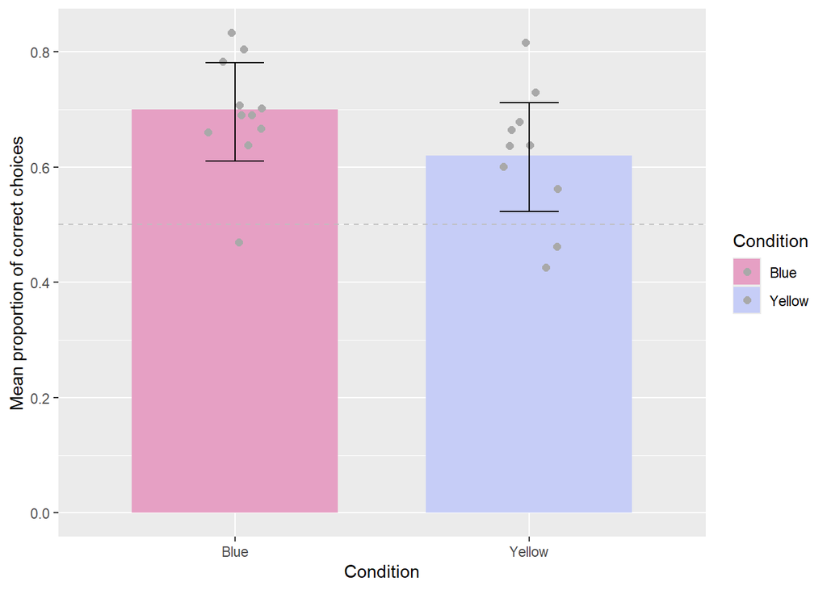

```r
testgraph <- ggplot(dframe, aes(x = condition, y = proportion, fill = condition)) +
  labs (x= "Condition", y = "Mean proportion of correct choices", fill="Condition") +
  geom_bar(stat = "identity", position = "dodge", width = .7) +
  geom_hline(yintercept = 0.5, linetype = "dashed", colour = "grey") +
  geom_point(data = meanpoints, aes(x = condition, y = prop), position = position_jitter(width=0.1), size =2,        colour="dark grey") +
  scale_fill_manual(values = wes_palette("GrandBudapest2", n = 2)) +
  geom_errorbar(aes(ymin = confintlow, ymax = confinthigh), width=.2)
print(testgraph)
```

Nice! Finally let’s try and make the overall graph look nicer. We can use geom_text to add a significance asterix at a specific coordinate on the graph (in this graph its not necessary but you can use this code when needed). We can also specify overall aesthetics requirements of the graph using “theme”, for example we use panel.background to remove the default background of the graph. We also remove the legend which we don’t need here.

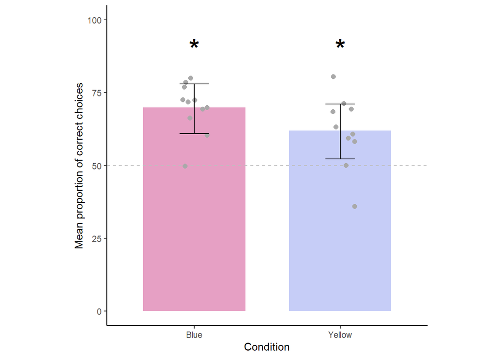

```r
testgraph <- ggplot(dframe, aes(x = condition, y = proportion, fill = condition)) +
  labs (x= "Condition", y = "Mean proportion of correct choices", fill="Condition") +
  geom_bar(stat = "identity", position = "dodge", width = .7) +
  geom_hline(yintercept = 0.5, linetype = "dashed", colour = "grey") +
  geom_point(data = meanpoints, aes(x = condition, y = prop), position = position_jitter(width=0.1), size =2,        colour="dark grey") +
  scale_fill_manual(values = wes_palette("GrandBudapest2", n = 2)) +
  geom_errorbar(aes(ymin = confintlow, ymax = confinthigh), width=.2) +
  geom_text(x="Blue", y = 0.9, label ="*", size =10) +
  geom_text(x="Yellow", y = 0.9, label ="*", size =10) +
  scale_y_continuous(labels = scales::percent_format(accuracy = 1, suffix = NULL), limits = c(0,1)) +
  theme(panel.background = element_blank(),
        axis.line = element_line(colour = "black"),
        aspect.ratio = 1/1,
        legend.position = "none")
print(testgraph)
```

Use the ggThemeAssist add-in to play around with the aesthetics. This add-in helps you customize your graph aesthetics and then automatically adds the code to your graph. You can view this code to better understand how ggplot works. Highlight the code and then click Add-ins and click on ggplot Theme Assistant. Now hopefully you have a good understanding of how ggplot works! All other graph types follow a similar principle, try removing individual lines from the above regression graphs to see what changes in the figure.

# **Simulation-based power analysis**

If you want to run a power analysis, I recommend simulation-based analysis, where you generate simulated datasets around a true effect. THen models are generated for each dataset to see if they can detect this true effect. We then calculate the percentage of models that succesffully detected the effect versus those that did not. Generally we want to detect the true effect above 80% of the time.

```r
# Parameters
n_bees <- 20 # how many bees
n_data_points <- 10 # how many data points
n_total <- n_bees * n_data_points
p1 <- 0.65  # What is the true effect you are trying to detect? Let's say learning of 65% accuracy
alpha <- 0.05
nsim <- 100  # Number of simulations, generally set to 1000 but here I did 100 only

# Function to simulate data with random effects
simulate_data <- function(n_bees, n_data_points, p, random_effect_sd) {
  bee_ids <- rep(1:n_bees, each = n_data_points)
  random_effects <- rnorm(n_bees, 0, random_effect_sd)
  choices <- sapply(1:n_total, function(i) {
    prob <- plogis(qlogis(p) + random_effects[bee_ids[i]])
    rbinom(1, 1, prob)
  })
  data.frame(bee_id = factor(bee_ids), choice = choices)
}

# General assumptions for random effect standard deviation
random_effect_sd <- 0.4418846 # aprior random effect standard deviation, you can just take a guess or check the values of previous models/experiments.

# Simulate data with the specified effect size
set.seed(123)  # For reproducibility
simulated_data <- simulate_data(n_bees, n_data_points, p1, random_effect_sd)

# Print the simulated dataframe
print(head(simulated_data))
```

```
##   bee_id choice
## 1      1      1
## 2      1      1
## 3      1      1
## 4      1      1
## 5      1      1
## 6      1      1
```

```r
summary(simulated_data)
```

```
##      bee_id        choice
##  1      : 10   Min.   :0.000
##  2      : 10   1st Qu.:0.000
##  3      : 10   Median :1.000
##  4      : 10   Mean   :0.685
##  5      : 10   3rd Qu.:1.000
##  6      : 10   Max.   :1.000
##  (Other):140
```

```r
# Initialize counter for significant results
significant_results <- 0

# Run simulations
for (i in 1:nsim) {
  # Simulate data under the alternative hypothesis
  simulated_data <- simulate_data(n_bees, n_data_points, p1, random_effect_sd)

  # Fit the model to the simulated data, make sure the model structure is correct
  model <- tryCatch({
    glmer(choice ~ 1 + (1 | bee_id), family = binomial(link = "logit"), data = simulated_data)
  }, error = function(e) {
    message("Error fitting model: ", e)
    return(NULL)
  })

  if (!is.null(model)) {
    # Extract p-value for the intercept
    p_value <- summary(model)$coefficients[1, "Pr(>|z|)"]

    # Check if p-value is below the significance level
    if (p_value < alpha) {
      significant_results <- significant_results + 1
    }
  }
}
```

[output not shown]

```r
# Calculate power
power_estimate <- significant_results / nsim
print(paste("Estimated Power: ", round(power_estimate, 3)))
```

```
## [1] "Estimated Power:  0.92"
```